# Statistics: The Science of Decisions Project

Arash Rahimgol

### Background Information

In a Stroop task, participants are presented with a list of words, with each word displayed in a color of ink. The participant’s task is to say out loud the color of the ink in which the word is printed. The task has two conditions: a congruent words condition, and an incongruent words condition. In the congruent words condition, the words being displayed are color words whose names match the colors in which they are printed: for example RED, BLUE. In the incongruent words condition, the words displayed are color words whose names do not match the colors in which they are printed: for example PURPLE, ORANGE. In each case, we measure the time it takes to name the ink colors in equally-sized lists. Each participant will go through and record a time from each condition.

### Questions For Investigation

#### 1. What is our independent variable? What is our dependent variable?

Independent variable: Incongruent, Congruent words condition.

Dependent variable: The time it takes to name the ink colors in equally-sized lists.

#### 2. What is an appropriate set of hypotheses for this task? What kind of statistical test do you expect to perform? Justify your choices.

This test is an intersubjective experiment with two conditions, Congruent and Incongruent. We set our null hypothesis so that there was no difference between the two conditions in the pace of naming ink colors. If we can reject the null hypothesis, we can prove the alternative hypothesis which means the word conditions caused differences in the outcomes.

Since we don't have the population parameters, we use two tailed t-Test with α = .001 on the average difference between two conditions.

Assume:

µ<sub>D</sub> = µ<sub>C</sub> - µ<sub>I</sub>

Then:

null --> H<sub>0</sub>: µ<sub>C</sub> = µ<sub>I</sub> --> µ<sub>D</sub> = 0

alt --> H<sub>1</sub>: µ<sub>C</sub> <> µ<sub>I</sub> --> µ<sub>D</sub> <> 0

Now it’s your chance to try out the Stroop task for yourself. Go to [this link](https://www.google.com/url?q=https%3A%2F%2Ffaculty.washington.edu%2Fchudler%2Fjava%2Fready.html&sa=D&sntz=1&usg=AFQjCNGc_1cOHZy4iwBhM93xXvCImuQ1sQ), which has a Java-based applet for performing the Stroop task. Record the times that you received on the task (you do not need to submit your times to the site.) Now, download [this dataset](https://drive.google.com/file/d/0B9Yf01UaIbUgQXpYb2NhZ29yX1U/view?usp=sharing) which contains results from a number of participants in the task. Each row of the dataset contains the performance for one participant, with the first number their results on the congruent task and the second number their performance on the incongruent task.

#### 3. Report some descriptive statistics regarding this dataset. Include at least one measure of central tendency and at least one measure of variability.

```python
import pandas as pd
```

```python
path = r'../data/stroopdata.csv'

dataFrame = pd.read_csv(path)
dataFrame['D'] = dataFrame['Congruent'] - dataFrame['Incongruent']
dataFrame
```

|  | Congruent | Incongruent | D |
| --- | --- | --- | --- |
| 0 | 12.079 | 19.278 | -7.199 |
| 1 | 16.791 | 18.741 | -1.950 |
| 2 | 9.564 | 21.214 | -11.650 |
| 3 | 8.630 | 15.687 | -7.057 |
| 4 | 14.669 | 22.803 | -8.134 |
| 5 | 12.238 | 20.878 | -8.640 |
| 6 | 14.692 | 24.572 | -9.880 |
| 7 | 8.987 | 17.394 | -8.407 |
| 8 | 9.401 | 20.762 | -11.361 |
| 9 | 14.480 | 26.282 | -11.802 |
| 10 | 22.328 | 24.524 | -2.196 |
| 11 | 15.298 | 18.644 | -3.346 |
| 12 | 15.073 | 17.510 | -2.437 |
| 13 | 16.929 | 20.330 | -3.401 |
| 14 | 18.200 | 35.255 | -17.055 |
| 15 | 12.130 | 22.158 | -10.028 |
| 16 | 18.495 | 25.139 | -6.644 |
| 17 | 10.639 | 20.429 | -9.790 |
| 18 | 11.344 | 17.425 | -6.081 |
| 19 | 12.369 | 34.288 | -21.919 |
| 20 | 12.944 | 23.894 | -10.950 |
| 21 | 14.233 | 17.960 | -3.727 |
| 22 | 19.710 | 22.058 | -2.348 |
| 23 | 16.004 | 21.157 | -5.153 |

```python
muArray = dataFrame.mean()
print 'Means:\n', muArray
```

```
Means:
Congruent      14.051125
Incongruent    22.015917
D              -7.964792
dtype: float64
```

```python
sigmaArray = dataFrame.std()
print 'Sigmas:\n', sigmaArray
```

```
Sigmas:
Congruent      3.559358
Incongruent    4.797057
D              4.864827
dtype: float64
```

#### 4. Provide one or two visualizations that show the distribution of the sample data. Write one or two sentences noting what you observe about the plot or plots.

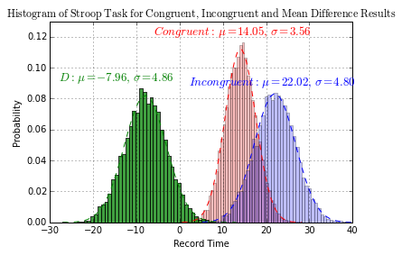

```python
%pylab inline

import numpy as np
import matplotlib.pyplot as plt
import matplotlib.mlab as mlab

colorArray=['r', 'b', 'g']
alphaArray=[0.25, 0.25, 0.75]

for idx in xrange(len(dataFrame.columns)):
    mu, sigma = muArray[idx], sigmaArray[idx]
    x = [mu + sigma * np.random.randn(10000)]
    n, bins, patches = plt.hist(x, 50, normed=1, color=colorArray[idx], alpha=alphaArray[idx])

    y = mlab.normpdf(bins, mu, sigma)
    l = plt.plot(bins, y, colorArray[idx]+'--', linewidth=1)

    plt.text(mu-20, max(n)+.005, r'$'+str(dataFrame.columns[idx])+':\ \mu='+str('%.2f' %mu)+
             ',\ \sigma='+str('%.2f' %sigma)+'$', fontsize=13, weight='bold', color=colorArray[idx])

plt.xlabel('Record Time')
plt.ylabel('Probability')
plt.axis([-30, 40, 0, 0.13])
plt.title(r'$\mathrm{Histogram\ of\ Stroop\ Task\ for\ Congruent,\ Incongruent\ and\ Mean\ Difference\ Results}$')

plt.grid(True)
plt.show()
```

We use µ<sub>D</sub> = µ<sub>C</sub> - µ<sub>I</sub> as our point estimate for the average of the population. To compare this average with other samples, we calculate the population standard deviation with Bessel's correction.

#### 5. Now, perform the statistical test and report your results. What is your confidence level and your critical statistic value? Do you reject the null hypothesis or fail to reject it? Come to a conclusion in terms of the experiment task. Did the results match up with your expectations?

n = 24

df = 23

α = 0.001

t <sub>critical</sub> = -3.768

Standard Error<sub>D</sub> = σ<sub>D</sub> / √n = 0.99

t <sub>statistic</sub> = µ<sub>D</sub> / Standard Error<sub>D</sub> = -8.02

Cohen's d = μ<sub>D</sub> / σ<sub>D</sub> = -1.64

r<sup>2</sup> = t <sub>statistic</sub><sup>2</sup> / (t <sub>statistic</sub><sup>2</sup> + df) = 0.74

#### Results:

t(23) = -8.02, p < .001, two-tailed

CI = [-11.71, -4.22]

d = -1.64 , r<sup>2</sup> = .74

Therefore we reject the null hypothesis H<sub>0</sub> which means that there is a significant difference between the results of Congruent and Incongruent conditions.

We can conclude that the ink color in which the word is printed has a causal effect on the results of Stroop test.

The result matched my expectation. The big r<sup>2</sup> shows that this Congruent-Incongruent conditions caused a significant difference in the results. Other lurking variables like age, gender and etc. can potentially be considered for hypothesis test.

#### 6. Optional: What do you think is responsible for the effects observed? Can you think of an alternative or similar task that would result in a similar effect? Some research about the problem will be helpful for thinking about these two questions!

A group of theories called "Race Models" are developed to explain the Stroop effect. These theories are based on the fact that brain processes the foreground and background information simultaneously, which may cause errors in selecting the appropriate response to stimuli. [[Wikipedia - Stroop Effect](https://en.wikipedia.org/wiki/Stroop_effect)]

In another classic experiment in cognitive science participants are similarly asked to match a simple geometric shape with its name. Again the performance of each subject is evaluated when the shape and name are similar (Congruent condition) and when the shape and the displayed name are different (Incongruent condition). The exact statistical test can be used to find out if any significant causes by changing in the conditions.